# CSSS 508: Homework 4

Key

Due 10/27/2022

# Instructions

For this assignment you will practice creating, examining, and combining different data structures in R. This assignment is different from others in that it takes a worksheet format with built-in error checking. Each time you complete an answer, if you knit the document it should check your answer (but don’t remove “NULL” on an answer before you want it checked or you’ll get an error!) For this reason, you should re-knit every time you answer a question, so that if something goes wrong, you know the last edit caused the issue!

You will need to do the following:

1. Fill in **code** as needed in the designated locations in code chunks.
   - You will not need to create new code chunks or edit chunk options.
   - Instructions in chunks will be shown as comments (after `#`); *remove* and *replace* the comments with your code:
   - Where you are assigning things to objects, replace the “NULL” values with your code. See code example 1 for an example!
   - You may need to add elements, such as for subsetting, to objects on the left side of operators. See code example 2 for an example!
   - Some answers may require multiple lines of code, so add as necessary.
   - Do not modify chunks labeled with “`# DO NOT EDIT`”; these are used to test your code.
2. Fill in **text** as block quotes (use `>`) in designated locations to answer questions.
   - Be brief and specific. If you reference a single value or short (<10 element) vector, use in-line R code. If the answer can be clearly and accurately answered without referencing any values, you can do so. When I bold a word in a question, take it to mean I want you to reference a value or values.
   - Do not directly reference matrices, lists, or data frames in text (don’t display them). They can be big!
   - You should not *need* to include any code *chunks* in this section, but you can if you need.

**Example for Code Questions:**

```r
# Ex 1) Create a vector of the numbers 1, 5, 3, 2, 4.
example <- NULL
# You would write this:
example <- c(1,5,3,2,4)
# Ex 2) Add the number 10 to the sixth position of example2
example2 <- example
example2 <- NULL
# You would write:
example2[6] <- 10
```

**Example for Text Questions:** 1) “How do vectors differ from lists?”

> A vector is a one dimensional object where every element is the same type of data. Lists are one dimensional but elements can be different data types.

# Problems

## 1: Coding with (Atomic) Vectors

```r
# 1) Use "seq()" to create a vector of 10 numbers evenly spaced from 0 to 15.
vec_num <- seq(0,15,by=15/9)
# 2) Use ":" to create an integer vector of the numbers 11 through 20.
vec_int <- 11:20
# 3) "LETTERS" contains the 26 capital letters in order. Use "LETTERS" and "[ ]" to create a vector of the last 10 capital letters.
vec_cha <- LETTERS[17:26]
# 4) Use letters and "[ ]" to create a factor variable using the first ten lower case letters.
vec_fac <- factor(letters[1:10])
# 5) Use "c()" to combine "vec_cha" and "vec_fac" into "vec_let". Do not convert it to a factor!
vec_let <- c(vec_cha,vec_fac)
# 6) Use "c()" and "[ ]" to combine the first 4 elements of "vec_num" with the last
# 4 elements of "vec_int" to create "vec_ni".
vec_ni <- c(vec_num[1:4],vec_int[7:10])
# 7) Use "rev()" to reverse the order of "vec_fac".
fac_vec <- rev(vec_fac)
```

*How’d you do?*

```
Good job on vec_num!
Good job on vec_int!
Good job on vec_cha!
Good job on vec_fac!
Good job on vec_let!
Good job on vec_ni!
Good job on fac_vec!
```

### Questions about Vectors:

1. If you used `c()` to combine `vec_int` with `vec_fac`, what *class* of vector would you get? Why?

> Answer: “integer”, because vectors can only be of one type and factors have an underlying numeric representation (as integers!)
2. Consider this code:

```r
new_vec <- c(TRUE, FALSE, TRUE, TRUE)
```

- What **class** of vector is this?
- In words, what happens to its values when you try to convert it to numeric? To character? To numeric and then character?
- What about to character and then numeric?

## 2: Coding with Matrices

```r
# 1) Use matrix() to create a matrix with 10 rows and four columns filled with NA
mat_empty <- matrix(NA,nrow=10,ncol=4)

# 2) Assign "vec_num" to the first column of "mat_1" below.
mat_1 <- mat_empty # DO NOT EDIT THIS LINE; add code below it.
mat_1[,1] <- vec_num

# 3) Assign "vec_int" to the second column of "mat_2" below
mat_2 <- mat_1 # DO NOT EDIT THIS LINE; add code below it.
mat_2[,2] <- vec_int

# 4) Assign "vec_cha" and "vec_fac" to the third and fourth columns of "mat_3" using one assignment operator.
mat_3 <- mat_2 # DO NOT EDIT THIS LINE; add code below it.
mat_3[,3:4] <- c(vec_cha,vec_fac)

# 5) Select the fourth row from "mat_3" and assign it to the object "row_4" as a vector.
row_4 <- mat_3[4,]

# 6) Assign the element in the 6th row and 2nd column of "mat_3" to "val_6_2" as a numeric value (using as.numeric).
val_6_2 <- as.numeric(mat_3[6,2])

# 7) Use "cbind()" to combine "vec_num", "vec_int", "vec_cha", and "vec_fac" into "mat_4".
mat_4 <- cbind(vec_num,vec_int,vec_cha,vec_fac)

# 8) Next, first transpose mat_4, then select only the first four columns and assign to mat_t
mat_t <- t(mat_4)[,1:4]

# 9)  Then use rbind() to add the rows from mat_3 to mat_t (mat_t first, mat_3 second) and assign this combination to mat_big.
mat_big <- rbind(mat_t,mat_3)
```

*How’d you do?*

```
Good job on mat_empty!
Good job on mat_1!
Good job on mat_2!
Good job on mat_3!
Good job on row_4!
Good job on val_6_2!
Good job on mat_4!
Good job on mat_t!
Good job on mat_big!
```

### Questions about Matrices:

1. Note the column names on mat_4. What do you get when you try to get `names()` from `mat_4`? What about `colnames()`? What about `rownames()`? Can you guess why you get all these results?

```r
mat_letters <- matrix(letters, ncol=2)
```

- This matrix goes from `"a"` to `"m"` in the first column and `"n"` to `"z"` in the second. What would be an easy way to make the matrix go in alphabetical order left to right, top to bottom?

```r
math_mat <- matrix(1:5, nrow=5, ncol=5)
math_vec <- 1:5
```

- Without showing your code (use the console), look at `math_mat` and `math_vec`. When you add `math_mat + math_vec`, what happens?
- Without showing your code (use the console), what is the difference between the results from `math_mat %*% math_vec` and from `math_mat * math_vec`. Can you tell what is happening?

> Answer: (1) the vector mat_vec is added to each columh of math_mat; (2) the first does matrix multiplication, while the second does element-wise multiplication.

## 3: Lists

```r
# 1) Use "list()" to create a list that contains "vec_num" and "row_4", and assign the names
#   "vec_num" and "row_4" to these two elements of "list_1".
list_1 <- list("vec_num"=vec_num,"row_4"=row_4)
# 2) Using "$", extract "row_4" from "list_1" and assign it to the object "row_4_2".
row_4_2 <- list_1$row_4
# 3) Create another list that contains "val_6_2" and "mat_big".
list_2 <- list("val_6_2"=val_6_2,"mat_big"=mat_big)
# 4) Combine list_1 and list_2 together using "c()" and assign them to "list_3"
list_3 <- c(list_1,list_2)
# 5) Use "unlist()" to turn "list_3" into a vector and assign it to "vector_3"
vector_3 <- unlist(list_3)
# 6) Use "as.list()" to convert "vector_3" into a list and assign it to "list_big"
list_big <- as.list(vector_3)
# 7) Now copy "list_3" as "list_4" (one line of code). Then use "[[ ]]" to assign "list_3" as the last (fifth) element of "list_4";
# that is, you should have a list object with five elements named "list_4" that contains the same four
# elements as "list_3" plus a fifth element that is -all- four elements of "list_3" as one object.
list_4 <- list_3
list_4[[5]] <- list_3
# 8) Select the third element (that is, the sub-element) of the the fifth element of "list_4" and assign it
# to element_5_3 using "[[ ]]".
element_5_3 <- list_4[[5]][[3]]
# 9) Lastly, repeat the previous assignment of the third element of the fifth element, but
# extract the element as a list rather than scalar using "[ ]" and assign it to "list_5_3".
list_5_3 <- list_4[[5]][3]
```

*How’d you do?*

```
Good job on list_1!
Good job on row_4_2!
Good job on list_2!
Good job on list_3!
Good job on vector_3!
Good job on list_big!
Good job on list_4!
Good job on element_5_3!
Good job on list_5_3!
```

### Questions About Lists:

Many functions in R produce lists as output because they produce objects with different types of data and of different lengths. For instance, consider the linear regression saved to `lm.output` below. Don’t worry if you are not familiar with regression, we’re just concerned with what the function produces!

```r
lm.output <- lm(mpg ~ wt, data=mtcars)
lm.output
```

```
##
## Call:
## lm(formula = mpg ~ wt, data = mtcars)
##
## Coefficients:
## (Intercept)           wt
##      37.285       -5.344
```

1. **How many elements** does this call to `lm()` produce? *Hint: use the function* `length()`.

> Answer: 12 (length(lm.output))
2. What are the **dimensions** of the `model` element?

> Answer: 32 rows and 2 columns (dim(lm.output$model))
3. What are the **values** of the `coefficients` for the `intercept` and `wt`? Remember to call on them from `lm.output` object for your answer!

> Answer: 37.285126 and -5.344472 (lm.output$coefficients)

## 4: Coding with Data Frames

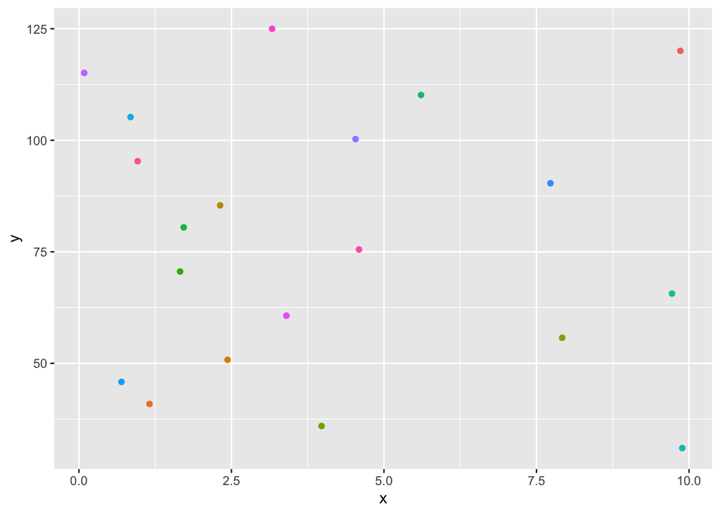

```r
# 1) Use "data.frame()" to combine "vec_num" (first column) and "vec_int" (second column) into "df_1".
df_1 <- data.frame(vec_num,vec_int)

# 2) Use "$" to extract "vec_num" from "df_1", reverse it with "rev()", and assign it as the vector "vec_num_2".
vec_num_2 <- rev(df_1$vec_num)

# 3) Use "$" to add "vec_num_2" to "df_2" as a new column with the name "number_vector".
df_2 <- df_1 # DO NOT EDIT THIS LINE; add code below it.
df_2$number_vector <- vec_num_2

# 4) Combine "df_2" with itself using "rbind()" to create "df_3"
df_3 <- rbind(df_2,df_2)

# 5) Create a new data frame "df_4" using "data.frame()" that contains the following named columns (in order):
    # "y" that contains 20 numbers evenly spaced from 31 to 125
    # "x" that has 20 numbers between 0 and 10 generated using "runif()" (get help with ?runif)
    # "color" that consists of 20 values sampled from "col_vec "below using "sample()".
col_vec <- colors() # DO NOT EDIT THIS LINE; add code below it.
df_4 <- data.frame(y=seq(31,125,length=20),
                   x=runif(20,min=0,max=10),
                   color=sample(col_vec,20))

    # This code here should produce a plot of those values with those colors!
if(is.null(df_4)==FALSE) df_4 %>% ggplot(aes(x, y, color=color)) + geom_point() + theme(legend.position="none")
```

```r
# 5) Use "cbind()" to combine "df_4" and "df_2" into "df_5".
df_5 <- cbind(df_4,df_2)

# 6) Now convert "df_5" into a data.frame using "data.frame()"
df_6 <- data.frame(df_5)
```

*How’d you do?*

```
Good job on df_1!
Good job on vec_num_2!
Good job on df_2!
Good job on df_3!
Good job on df_4!
Good job on df_5!
Good job on df_6!
```

### Questions About Data Frames:

1. Use `names()`, `colnames()`, and `rownames()` on df_1. How does this compare to the behavior of these functions on lists and matrices?

> Answer: All these functions “work” now! names and colnames tell us the vector names, while rownames is just the numbers between 1 and 10.
2. Similarly, how do the results of `length()` and `dim()` differ between data frames, lists, matrices, and vectors?

> Answer: length gives number of columns in a dataframe, number of elents in a list, number of total numbers in a matrix, and length of a vector. dim gives number of rows/columsn for data frames and matrices, but doesn’t work for lists and vectors.
3. Using the console, use `==` to test to see if `cbind()` and `data.frame()` in questions 5 and 6 produce the same result. That is, run the code `df_5 == df_6` and describe the answer. What does this tell us about `cbind` and `data.frame`?

> Answer: They are still equal (element_wise). This tells us the cbind and data.frame are ultimately functioning to accomplish the same task in this case.